# Risk Factor Analysis

## Outcome Variable

**Outcome Variable:** s03rec24

## Predictor Variables

**Intervention Variable:** hdlvry

**Adjustment Set:**

unadjusted

## Stratifying Variables

The analysis was stratified on these variable(s):

- studyid
- country

## Data Summary

| studyid | country | hdlvry | s03rec24 | n_cell | n |
| --- | --- | --- | --- | --- | --- |
| ki1000108-CMC-V-BCS-2002 | INDIA | 0 | 0 | 344 | 367 |
| ki1000108-CMC-V-BCS-2002 | INDIA | 0 | 1 | 15 | 367 |
| ki1000108-CMC-V-BCS-2002 | INDIA | 1 | 0 | 7 | 367 |
| ki1000108-CMC-V-BCS-2002 | INDIA | 1 | 1 | 1 | 367 |
| ki1000108-IRC | INDIA | 0 | 0 | 374 | 410 |
| ki1000108-IRC | INDIA | 0 | 1 | 28 | 410 |
| ki1000108-IRC | INDIA | 1 | 0 | 8 | 410 |
| ki1000108-IRC | INDIA | 1 | 1 | 0 | 410 |
| ki1000109-EE | PAKISTAN | 0 | 0 | 240 | 346 |
| ki1000109-EE | PAKISTAN | 0 | 1 | 0 | 346 |
| ki1000109-EE | PAKISTAN | 1 | 0 | 106 | 346 |
| ki1000109-EE | PAKISTAN | 1 | 1 | 0 | 346 |
| ki1017093b-PROVIDE | BANGLADESH | 0 | 0 | 494 | 690 |
| ki1017093b-PROVIDE | BANGLADESH | 0 | 1 | 18 | 690 |
| ki1017093b-PROVIDE | BANGLADESH | 1 | 0 | 174 | 690 |
| ki1017093b-PROVIDE | BANGLADESH | 1 | 1 | 4 | 690 |
| ki1066203-TanzaniaChild2 | TANZANIA, UNITED REPUBLIC OF | 0 | 0 | 2125 | 2163 |
| ki1066203-TanzaniaChild2 | TANZANIA, UNITED REPUBLIC OF | 0 | 1 | 1 | 2163 |
| ki1066203-TanzaniaChild2 | TANZANIA, UNITED REPUBLIC OF | 1 | 0 | 37 | 2163 |
| ki1066203-TanzaniaChild2 | TANZANIA, UNITED REPUBLIC OF | 1 | 1 | 0 | 2163 |
| ki1113344-GMS-Nepal | NEPAL | 0 | 0 | 270 | 1108 |
| ki1113344-GMS-Nepal | NEPAL | 0 | 1 | 6 | 1108 |
| ki1113344-GMS-Nepal | NEPAL | 1 | 0 | 812 | 1108 |
| ki1113344-GMS-Nepal | NEPAL | 1 | 1 | 20 | 1108 |

The following strata were considered:

- studyid: ki1000108-CMC-V-BCS-2002, country: INDIA
- studyid: ki1000108-IRC, country: INDIA
- studyid: ki1000109-EE, country: PAKISTAN
- studyid: ki1017093b-PROVIDE, country: BANGLADESH
- studyid: ki1066203-TanzaniaChild2, country: TANZANIA, UNITED REPUBLIC OF
- studyid: ki1113344-GMS-Nepal, country: NEPAL

### Dropped Strata

Some strata were dropped due to rare outcomes:

- studyid: ki1000108-CMC-V-BCS-2002, country: INDIA
- studyid: ki1000108-IRC, country: INDIA
- studyid: ki1000109-EE, country: PAKISTAN
- studyid: ki1017093b-PROVIDE, country: BANGLADESH
- studyid: ki1066203-TanzaniaChild2, country: TANZANIA, UNITED REPUBLIC OF

## Methods Detail

We’re interested in the causal parameters $E[Y_a]$ for all values of $a \in \mathcal{A}$. These parameters represent the mean outcome if, possibly contrary to fact, we intervened to set all units to have $A=a$. Under the randomization and positivity assumptions, these are identified by the statistical parameters $\psi_a=E_W[E_{Y|A,W}(Y|A=a,W)]$. In addition, we’re interested in the mean of $Y$, $E[Y]$ under no intervention (the observed mean). We will estimate these parameters by using SuperLearner to fit the relevant likelihood factors – $E_{Y|A,W}(Y|A=a,W)$ and $p(A=a|W)$, and then updating our likelihood fit using a joint TMLE.

For unadjusted analyses ($W=\{\}$), initial likelihoods were estimated using Lrnr_glm to estimate the simple $E(Y|A)$ and Lrnr_mean to estimate $p(A)$. For adjusted analyses, a small library containing Lrnr_glmnet, Lrnr_xgboost, and Lrnr_mean was used.

Having estimated these parameters, we will then use the delta method to estimate relative risks and attributable risks relative to a prespecified baseline level of $A$.

# Results Detail

## Results Plots

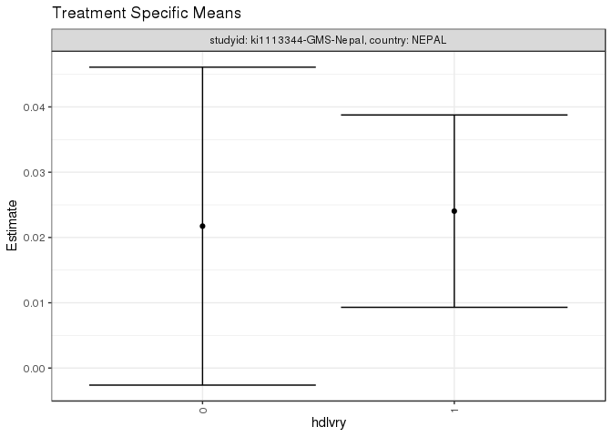

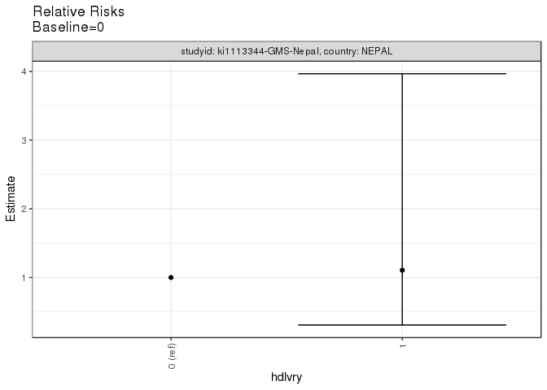

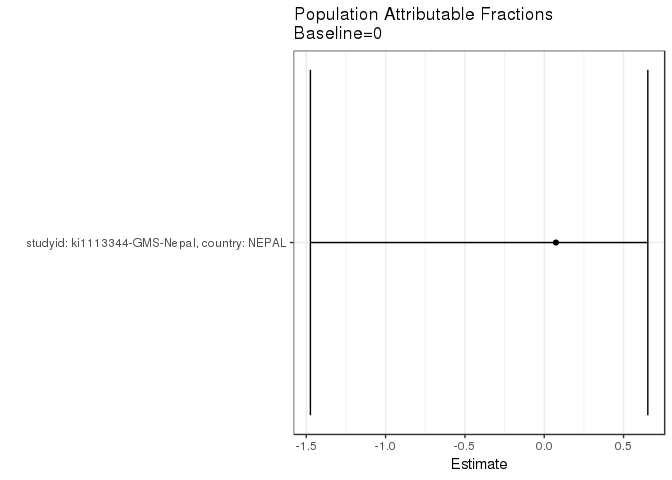

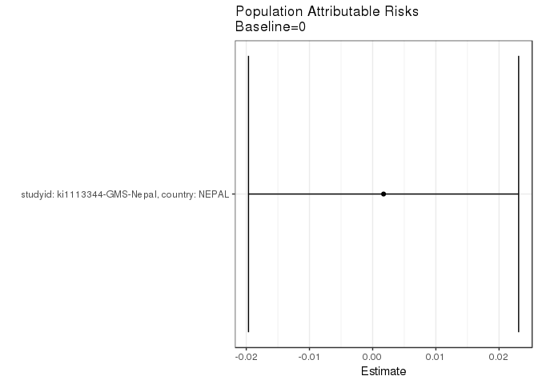

## Results Table

### Parameter: TSM

| studyid | country | intervention_level | baseline_level | estimate | ci_lower | ci_upper |
| --- | --- | --- | --- | --- | --- | --- |
| ki1113344-GMS-Nepal | NEPAL | 0 | NA | 0.0217391 | -0.0026137 | 0.0460920 |
| ki1113344-GMS-Nepal | NEPAL | 1 | NA | 0.0240385 | 0.0093064 | 0.0387705 |

### Parameter: E(Y)

| studyid | country | intervention_level | baseline_level | estimate | ci_lower | ci_upper |
| --- | --- | --- | --- | --- | --- | --- |
| ki1113344-GMS-Nepal | NEPAL | NA | NA | 0.0234657 | 0.010849 | 0.0360824 |

### Parameter: RR

| studyid | country | intervention_level | baseline_level | estimate | ci_lower | ci_upper |
| --- | --- | --- | --- | --- | --- | --- |
| ki1113344-GMS-Nepal | NEPAL | 0 | 0 | 1.000000 | 1.0000000 | 1.000000 |
| ki1113344-GMS-Nepal | NEPAL | 1 | 0 | 1.105769 | 0.3083959 | 3.964792 |

### Parameter: PAR

| studyid | country | intervention_level | baseline_level | estimate | ci_lower | ci_upper |
| --- | --- | --- | --- | --- | --- | --- |
| ki1113344-GMS-Nepal | NEPAL | 0 | NA | 0.0017266 | -0.0196459 | 0.023099 |

### Parameter: PAF

| studyid | country | intervention_level | baseline_level | estimate | ci_lower | ci_upper |
| --- | --- | --- | --- | --- | --- | --- |
| ki1113344-GMS-Nepal | NEPAL | 0 | NA | 0.0735786 | -1.473961 | 0.6530839 |